# Whole game - Data visualization

# Whole game

## 1. Data visualization

With ggplot2

```r
# Loading the package

library(tidyverse)

# Data sets we will be using

library(palmerpenguins)
library(ggthemes)
```

### Penguins data frame

**Our ultimate job is to display the relationship between flipper lengths and body masses, taking into consideration the species of the penguin**

Variable -> Quantity, quality or property you can measure (variable refers to an attribute that all penguins have)

Value -> state of a variable

Oberservation -> set of measurements made under similar conditions (all atributes of a single penguin)

Tabular data -> set of values, each associated with a variable and an observation

```r
penguins
```

| species | island | bill_length_mm | bill_depth_mm | flipper_length_mm | body_mass_g | sex | year |
| --- | --- | --- | --- | --- | --- | --- | --- |
| Adelie | Torgersen | 39.1 | 18.7 | 181 | 3750 | male | 2007 |
| Adelie | Torgersen | 39.5 | 17.4 | 186 | 3800 | female | 2007 |
| Adelie | Torgersen | 40.3 | 18.0 | 195 | 3250 | female | 2007 |
| Adelie | Torgersen | NA | NA | NA | NA | NA | 2007 |
| Adelie | Torgersen | 36.7 | 19.3 | 193 | 3450 | female | 2007 |
| Adelie | Torgersen | 39.3 | 20.6 | 190 | 3650 | male | 2007 |
| Adelie | Torgersen | 38.9 | 17.8 | 181 | 3625 | female | 2007 |
| Adelie | Torgersen | 39.2 | 19.6 | 195 | 4675 | male | 2007 |
| Adelie | Torgersen | 34.1 | 18.1 | 193 | 3475 | NA | 2007 |
| Adelie | Torgersen | 42.0 | 20.2 | 190 | 4250 | NA | 2007 |

[output cut: 334 more lines]

Variables as columns

```r
glimpse(penguins)
```

```
Rows: 344
Columns: 8
$ species           <fct> Adelie, Adelie, Adelie, Adelie, Adelie, Adelie, Adelie, Adelie, Adelie, Adelie, Adelie,…
$ island            <fct> Torgersen, Torgersen, Torgersen, Torgersen, Torgersen, Torgersen, Torgersen, Torgersen,…
$ bill_length_mm    <dbl> 39.1, 39.5, 40.3, NA, 36.7, 39.3, 38.9, 39.2, 34.1, 42.0, 37.8, 37.8, 41.1, 38.6, 34.6,…
$ bill_depth_mm     <dbl> 18.7, 17.4, 18.0, NA, 19.3, 20.6, 17.8, 19.6, 18.1, 20.2, 17.1, 17.3, 17.6, 21.2, 21.1,…
$ flipper_length_mm <int> 181, 186, 195, NA, 193, 190, 181, 195, 193, 190, 186, 180, 182, 191, 198, 185, 195, 197…
$ body_mass_g       <int> 3750, 3800, 3250, NA, 3450, 3650, 3625, 4675, 3475, 4250, 3300, 3700, 3200, 3800, 4400,…
$ sex               <fct> male, female, female, NA, female, male, female, male, NA, NA, NA, NA, female, male, mal…
$ year              <int> 2007, 2007, 2007, 2007, 2007, 2007, 2007, 2007, 2007, 2007, 2007, 2007, 2007, 2007, 200…
```

### Creating a ggplot

- mapping -> how variables are going to be mapped
- aes() -> define x and y axes
- geom -> geometrical object used to represent data
- color (inside of mapping) -> color based on the mapped points

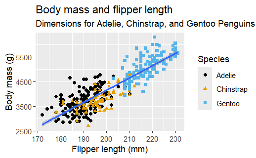

```r
ggplot(
  data = penguins,
  mapping = aes(x = flipper_length_mm, y = body_mass_g)
) +
  geom_point(mapping = aes(color = species, shape = species)) +
  geom_smooth(method = "lm") +
  labs(
    title = "Body mass and flipper length",
    subtitle = "Dimensions for Adelie, Chinstrap, and Gentoo Penguins",
    x = "Flipper length (mm)", y = "Body mass (g)",
    color = "Species", shape =  "Species"
  ) +

  scale_color_colorblind()
```

*As the flipper length increases, so does the body mass. It is failry linear and strong*

### Exercises

**How many rows are in penguins? How many columns?**

344 rows and 8 columns

**What does the bill_depth_mm variable in the penguins data frame describe? Read the help for ?penguins to find out.**

It describes as “a number denoting bill depth (millimeters)”

**Make a scatterplot of bill_depth_mm vs. bill_length_mm. That is, make a scatterplot with bill_depth_mm on the y-axis and bill_length_mm on the x-axis. Describe the relationship between these two variables.**

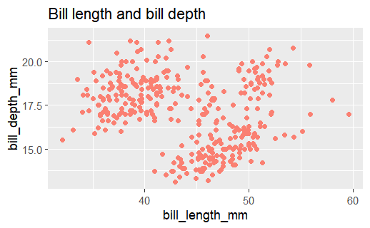

```r
ggplot(
  data = penguins,
  aes(x = bill_length_mm, y = bill_depth_mm)
       ) +
  geom_point(color="salmon") +
  labs(
    title = "Bill length and bill depth"
  )
```

**What happens if you make a scatterplot of species vs. bill_depth_mm? What might be a better choice of geom?**

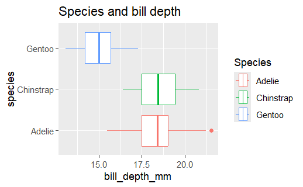

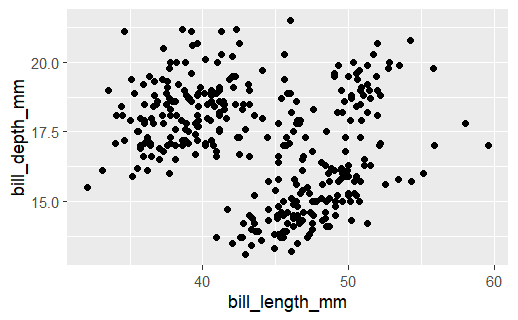

```r
ggplot(
  data = penguins,
  mapping = aes(x = bill_length_mm, y = bill_depth_mm)
) +
  geom_point(na.rm = TRUE)
```

**What does the na.rm argument do in geom_point()? What is the default value of the argument? Create a scatterplot where you successfully use this argument set to TRUE.**

The na.rm = TRUE removes the warnings regarding the lack of data in a concrete observation

```r
ggplot(
  data = penguins,
  mapping = aes(x = bill_length_mm, y = bill_depth_mm)
) +
  geom_point(na.rm = TRUE)
```

[output not shown]

**Add the following caption to the plot you made in the previous exercise: “Data come from the palmerpenguins package.” Hint: Take a look at the documentation for labs().**

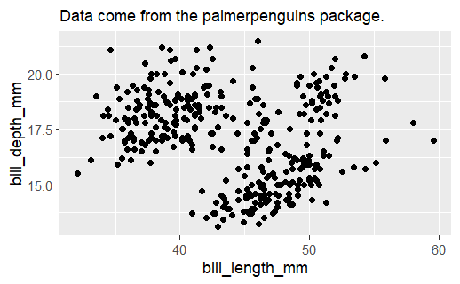

```r
ggplot(
  data = penguins,
  mapping = aes(x = bill_length_mm, y = bill_depth_mm)
) +
  geom_point(na.rm = TRUE) +
  labs(
    subtitle = "Data come from the palmerpenguins package."
  )
```

**Recreate the following visualization. What aesthetic should bill_depth_mm be mapped to? And should it be mapped at the global level or at the geom level?**

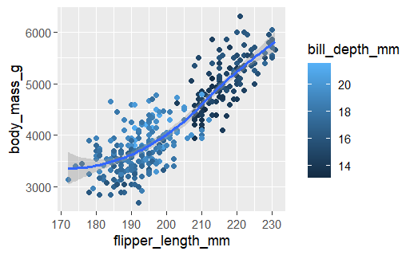

```r
ggplot(
  penguins,
  aes(x = flipper_length_mm, y = body_mass_g)
) +
  geom_point(aes(color = bill_depth_mm)) +
  geom_smooth(mthod = "lm")
```

**Run this code in your head and predict what the output will look like. Then, run the code in R and check your predictions**

It’s going to be a scatterplot, coloing the points based on from which island are the penguins and there will be some kind of regression line

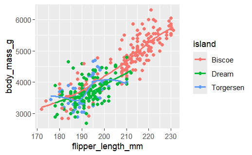

```r
ggplot(
  data = penguins,
  mapping = aes(x = flipper_length_mm, y = body_mass_g, color = island)
) +
  geom_point() +
  geom_smooth(se = FALSE)
```

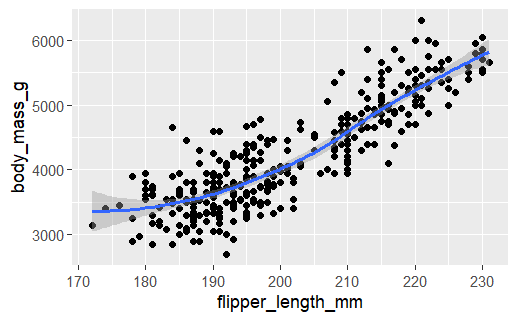

```r
ggplot() +
  geom_point(
    data = penguins,
    mapping = aes(x = flipper_length_mm, y = body_mass_g)
  ) +
  geom_smooth(
    data = penguins,
    mapping = aes(x = flipper_length_mm, y = body_mass_g)
  )
```

### Visualizing

Bar charts -> used for categorical variables

Fct_infreq orders the levels based on the frequency.

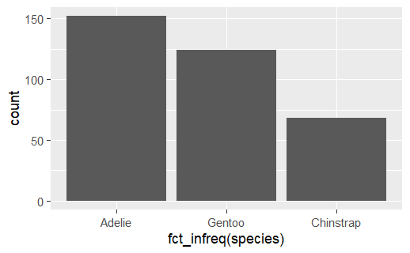

```r
ggplot(penguins, aes(x = fct_infreq(species))) +
  geom_bar()
```

Histogram -> Takes quantitative variables

Binwidth determines the width of the interval in a histogram

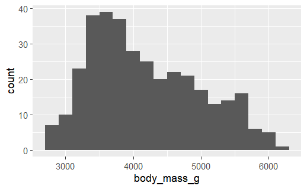

```r
ggplot(penguins, aes(x = body_mass_g)) +
  geom_histogram(binwidth = 200)
```

Density plot -> Quantitative variables (a smoothed out version of a hitogram)

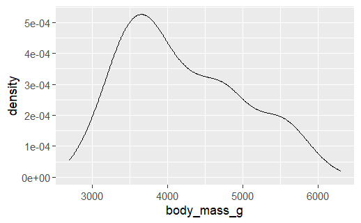

```r
ggplot(penguins, aes(x = body_mass_g)) +
  geom_density()
```

### Exercises

**Make a bar plot of species of penguins, where you assign species to the y aesthetic. How is this plot different?**

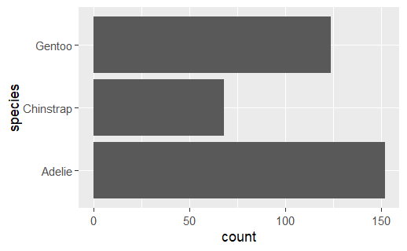

```r
penguins |>
  ggplot(aes(y=species)) +
  geom_bar()
```

This plot is different because it is plotted horizontally

The fill one colors in the bars and the color one just the outside of the bars

**What does the bins argument in geom_histogram() do?**

It determines the width of each one of the bars.

**Make a histogram of the carat variable in the diamonds dataset that is available when you load the tidyverse package. Experiment with different binwidths. What binwidth reveals the most interesting patterns?**

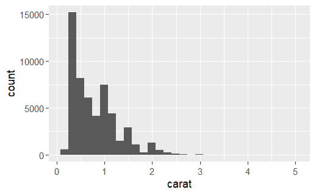

```r
ggplot(diamonds, aes(x = carat)) +
  geom_histogram(bindwidth = 0.01)
```

### Visualizing relationships

**Box plot** -> - useful for outliers - Interquartile range: from 25th percentile to 75th percentile - Middle of the box is the median (50th percentile) - Edge of the box is 1.5 times de IQR - Whiskers fo to the farthest non-outlier point in the distribution

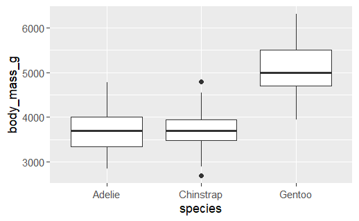

```r
ggplot(penguins, aes(x = species, y = body_mass_g)) +
  geom_boxplot(na.rm = TRUE)
```

They are similar to density plots

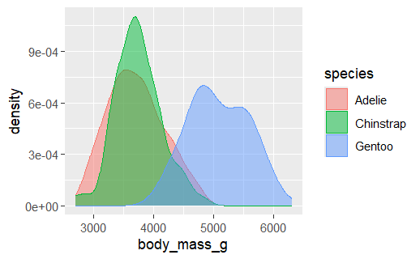

```r
ggplot(penguins, aes(x = body_mass_g, color = species, fill=species)) +
  geom_density(alpha=0.5, na.rm=TRUE)
```

**Bar graphs** ->

- For two categorical variables

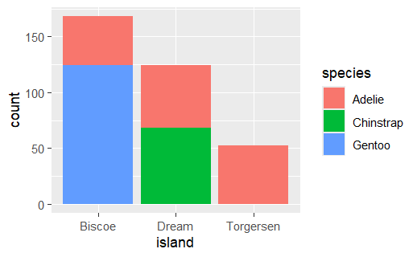

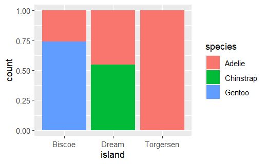

**Scatterplot** ->

- Visualizes the relationship between two numerical values

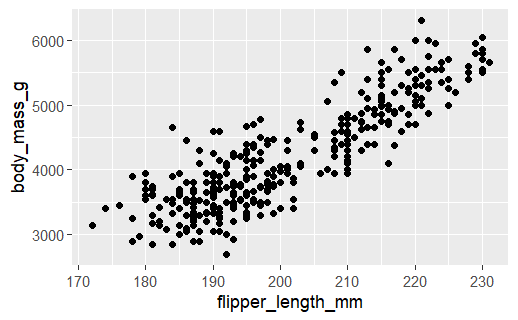

```r
ggplot(penguins, aes(x = flipper_length_mm, y = body_mass_g)) +
  geom_point(na.rm=TRUE)
```

- Can be also used for three or more variables

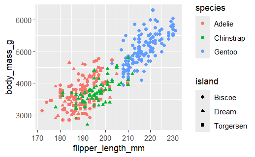

It can also be divided into facets. THe argument in facets has to be categorical.

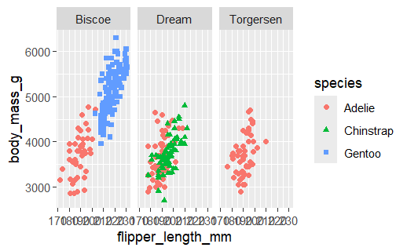

```r
ggplot(penguins, aes(x = flipper_length_mm, y = body_mass_g)) +
  geom_point(aes(color = species, shape = species), na.rm=TRUE) +
  facet_wrap(~island)
```